{% raw %}

{% endraw %} {% raw %}

{% endraw %} {% raw %}

{% endraw %}

GAN stands for [Generative Adversarial Nets](https://arxiv.org/pdf/1406.2661.pdf) and were invented by Ian Goodfellow. The concept is that we train two models at the same time: a generator and a critic. The generator will try to make new images similar to the ones in a dataset, and the critic will try to classify real images from the ones the generator does. The generator returns images, the critic a single number (usually a probability, 0. for fake images and 1. for real ones).

We train them against each other in the sense that at each step (more or less), we:

1. Freeze the generator and train the critic for one step by:
   - getting one batch of true images (let's call that `real`)
   - generating one batch of fake images (let's call that `fake`)
   - have the critic evaluate each batch and compute a loss function from that; the important part is that it rewards positively the detection of real images and penalizes the fake ones
   - update the weights of the critic with the gradients of this loss
1. Freeze the critic and train the generator for one step by:
   - generating one batch of fake images
   - evaluate the critic on it
   - return a loss that rewards positively the critic thinking those are real images
   - update the weights of the generator with the gradients of this loss

{% include note.html content='The fastai library provides support for training GANs through the GANTrainer, but doesn’t include more than basic models.' %}

## Wrapping the modules

{% raw %}

`class` `GANModule`[[source]](https://github.com/fastai/fastai/tree/master/fastai/vision/gan.py#L18)

> `GANModule`(**`generator`**:`nn.Module`=*`None`*, **`critic`**:`nn.Module`=*`None`*, **`gen_mode`**:`(None, bool)`=*`False`*) :: `Module`

Wrapper around a `generator` and a `critic` to create a GAN.

|  | Type | Default | Details |
| --- | --- | --- | --- |
| **`generator`** | `nn.Module` | `None` | The generator PyTorch module |
| **`critic`** | `nn.Module` | `None` | The discriminator PyTorch module |
| **`gen_mode`** | `(None, bool)` | `False` | Whether the GAN should be set to generator mode |

{% endraw %} {% raw %}

{% endraw %}

This is just a shell to contain the two models. When called, it will either delegate the input to the `generator` or the `critic` depending of the value of `gen_mode`.

{% raw %}

`GANModule.switch`[[source]](https://github.com/fastai/fastai/tree/master/fastai/vision/gan.py#L32)

> `GANModule.switch`(**`gen_mode`**:`(None, bool)`=*`None`*)

Put the module in generator mode if `gen_mode` is `True`, in critic mode otherwise.

|  | Type | Default | Details |
| --- | --- | --- | --- |
| **`gen_mode`** | `(None, bool)` | `None` | Whether the GAN should be set to generator mode |

{% endraw %}

By default (leaving `gen_mode` to `None`), this will put the module in the other mode (critic mode if it was in generator mode and vice versa).

{% raw %}

`basic_critic`[[source]](https://github.com/fastai/fastai/tree/master/fastai/vision/gan.py#L39)

> `basic_critic`(**`in_size`**:`int`, **`n_channels`**:`int`, **`n_features`**:`int`=*`64`*, **`n_extra_layers`**:`int`=*`0`*, **`norm_type`**:`NormType`=*`<NormType.Batch: 1>`*, **`ks`**=*`3`*, **`stride`**=*`1`*, **`padding`**=*`None`*, **`bias`**=*`None`*, **`ndim`**=*`2`*, **`bn_1st`**=*`True`*, **`act_cls`**=*`ReLU`*, **`transpose`**=*`False`*, **`init`**=*`'auto'`*, **`xtra`**=*`None`*, **`bias_std`**=*`0.01`*, **`dilation`**:`Union`[`int`, `typing.Tuple[int, int]`]=*`1`*, **`groups`**:`int`=*`1`*, **`padding_mode`**:`str`=*`'zeros'`*, **`device`**=*`None`*, **`dtype`**=*`None`*)

A basic critic for images `n_channels` x `in_size` x `in_size`.

|  | Type | Default | Details |
| --- | --- | --- | --- |
| **`in_size`** | `int` |  | Input size for the critic (same as the output size of the generator) |
| **`n_channels`** | `int` |  | Number of channels of the input for the critic |
| **`n_features`** | `int` | `64` | Number of features used in the critic |
| **`n_extra_layers`** | `int` | `0` | Number of extra hidden layers in the critic |
| **`norm_type`** | `NormType` | `NormType.Batch` | Type of normalization to use in the critic |
|  |  | **Valid Keyword Arguments** |  |
| **`ks`** | `int` | `3` | Argument passed to `ConvLayer.__init__` |
| **`stride`** | `int` | `1` | Argument passed to `ConvLayer.__init__` |
| **`padding`** |  | `None` | Argument passed to `ConvLayer.__init__` |
| **`bias`** |  | `None` | Argument passed to `ConvLayer.__init__` |
| **`ndim`** | `int` | `2` | Argument passed to `ConvLayer.__init__` |
| **`bn_1st`** | `bool` | `True` | Argument passed to `ConvLayer.__init__` |
| **`act_cls`** | `type` | `ReLU` | Argument passed to `ConvLayer.__init__` |
| **`transpose`** | `bool` | `False` | Argument passed to `ConvLayer.__init__` |
| **`init`** | `str` | `auto` | Argument passed to `ConvLayer.__init__` |
| **`xtra`** |  | `None` | Argument passed to `ConvLayer.__init__` |
| **`bias_std`** | `float` | `0.01` | Argument passed to `ConvLayer.__init__` |
| **`dilation`** | `typing.Union[int, typing.Tuple[int, int]]` | `1` | Argument passed to `ConvLayer.__init__` |
| **`groups`** | `int` | `1` | Argument passed to `ConvLayer.__init__` |
| **`padding_mode`** | `str` | `zeros` | Argument passed to `ConvLayer.__init__` |
| **`device`** |  | `None` | Argument passed to `ConvLayer.__init__` |
| **`dtype`** |  | `None` | Argument passed to `ConvLayer.__init__` |
| **Returns** | `nn.Sequential` |  |  |

{% endraw %} {% raw %}

{% endraw %} {% raw %}

`class` `AddChannels`[[source]](https://github.com/fastai/fastai/tree/master/fastai/vision/gan.py#L60)

> `AddChannels`(**`n_dim`**) :: `Module`

Add `n_dim` channels at the end of the input.

{% endraw %} {% raw %}

{% endraw %} {% raw %}

`basic_generator`[[source]](https://github.com/fastai/fastai/tree/master/fastai/vision/gan.py#L66)

> `basic_generator`(**`out_size`**:`int`, **`n_channels`**:`int`, **`in_sz`**:`int`=*`100`*, **`n_features`**:`int`=*`64`*, **`n_extra_layers`**:`int`=*`0`*, **`ks`**=*`3`*, **`stride`**=*`1`*, **`padding`**=*`None`*, **`bias`**=*`None`*, **`ndim`**=*`2`*, **`norm_type`**=*`<NormType.Batch: 1>`*, **`bn_1st`**=*`True`*, **`act_cls`**=*`ReLU`*, **`transpose`**=*`False`*, **`init`**=*`'auto'`*, **`xtra`**=*`None`*, **`bias_std`**=*`0.01`*, **`dilation`**:`Union`[`int`, `typing.Tuple[int, int]`]=*`1`*, **`groups`**:`int`=*`1`*, **`padding_mode`**:`str`=*`'zeros'`*, **`device`**=*`None`*, **`dtype`**=*`None`*)

A basic generator from `in_sz` to images `n_channels` x `out_size` x `out_size`.

|  | Type | Default | Details |
| --- | --- | --- | --- |
| **`out_size`** | `int` |  | Output size for the generator (same as the input size for the critic) |
| **`n_channels`** | `int` |  | Number of channels of the output of the generator |
| **`in_sz`** | `int` | `100` | Size of the input noise vector for the generator |
| **`n_features`** | `int` | `64` | Number of features used in the generator |
| **`n_extra_layers`** | `int` | `0` | Number of extra hidden layers in the generator |
|  |  | **Valid Keyword Arguments** |  |
| **`ks`** | `int` | `3` | Argument passed to `ConvLayer.__init__` |
| **`stride`** | `int` | `1` | Argument passed to `ConvLayer.__init__` |
| **`padding`** |  | `None` | Argument passed to `ConvLayer.__init__` |
| **`bias`** |  | `None` | Argument passed to `ConvLayer.__init__` |
| **`ndim`** | `int` | `2` | Argument passed to `ConvLayer.__init__` |
| **`norm_type`** | `(NormType.Batch, NormType.BatchZero, NormType.Weight, NormType.Spectral, NormType.Instance, NormType.InstanceZero)` | `NormType.Batch` | Argument passed to `ConvLayer.__init__` |
| **`bn_1st`** | `bool` | `True` | Argument passed to `ConvLayer.__init__` |
| **`act_cls`** | `type` | `ReLU` | Argument passed to `ConvLayer.__init__` |
| **`transpose`** | `bool` | `False` | Argument passed to `ConvLayer.__init__` |
| **`init`** | `str` | `auto` | Argument passed to `ConvLayer.__init__` |
| **`xtra`** |  | `None` | Argument passed to `ConvLayer.__init__` |
| **`bias_std`** | `float` | `0.01` | Argument passed to `ConvLayer.__init__` |
| **`dilation`** | `typing.Union[int, typing.Tuple[int, int]]` | `1` | Argument passed to `ConvLayer.__init__` |
| **`groups`** | `int` | `1` | Argument passed to `ConvLayer.__init__` |
| **`padding_mode`** | `str` | `zeros` | Argument passed to `ConvLayer.__init__` |
| **`device`** |  | `None` | Argument passed to `ConvLayer.__init__` |
| **`dtype`** |  | `None` | Argument passed to `ConvLayer.__init__` |
| **Returns** | `nn.Sequential` |  |  |

{% endraw %} {% raw %}

{% endraw %} {% raw %}

```python
critic = basic_critic(64, 3)
generator = basic_generator(64, 3)
tst = GANModule(critic=critic, generator=generator)
real = torch.randn(2, 3, 64, 64)
real_p = tst(real)
test_eq(real_p.shape, [2,1])

tst.switch() #tst is now in generator mode
noise = torch.randn(2, 100)
fake = tst(noise)
test_eq(fake.shape, real.shape)

tst.switch() #tst is back in critic mode
fake_p = tst(fake)
test_eq(fake_p.shape, [2,1])
```

{% endraw %} {% raw %}

{% endraw %} {% raw %}

`DenseResBlock`[[source]](https://github.com/fastai/fastai/tree/master/fastai/vision/gan.py#L95)

> `DenseResBlock`(**`nf`**:`int`, **`norm_type`**:`NormType`=*`<NormType.Batch: 1>`*, **`ks`**=*`3`*, **`stride`**=*`1`*, **`padding`**=*`None`*, **`bias`**=*`None`*, **`ndim`**=*`2`*, **`bn_1st`**=*`True`*, **`act_cls`**=*`ReLU`*, **`transpose`**=*`False`*, **`init`**=*`'auto'`*, **`xtra`**=*`None`*, **`bias_std`**=*`0.01`*, **`dilation`**:`Union`[`int`, `typing.Tuple[int, int]`]=*`1`*, **`groups`**:`int`=*`1`*, **`padding_mode`**:`str`=*`'zeros'`*, **`device`**=*`None`*, **`dtype`**=*`None`*)

Resnet block of `nf` features. `conv_kwargs` are passed to `conv_layer`.

|  | Type | Default | Details |
| --- | --- | --- | --- |
| **`nf`** | `int` |  | Number of features |
| **`norm_type`** | `NormType` | `NormType.Batch` | Normalization type |
|  |  | **Valid Keyword Arguments** |  |
| **`ks`** | `int` | `3` | Argument passed to `ConvLayer.__init__` |
| **`stride`** | `int` | `1` | Argument passed to `ConvLayer.__init__` |
| **`padding`** |  | `None` | Argument passed to `ConvLayer.__init__` |
| **`bias`** |  | `None` | Argument passed to `ConvLayer.__init__` |
| **`ndim`** | `int` | `2` | Argument passed to `ConvLayer.__init__` |
| **`bn_1st`** | `bool` | `True` | Argument passed to `ConvLayer.__init__` |
| **`act_cls`** | `type` | `ReLU` | Argument passed to `ConvLayer.__init__` |
| **`transpose`** | `bool` | `False` | Argument passed to `ConvLayer.__init__` |
| **`init`** | `str` | `auto` | Argument passed to `ConvLayer.__init__` |
| **`xtra`** |  | `None` | Argument passed to `ConvLayer.__init__` |
| **`bias_std`** | `float` | `0.01` | Argument passed to `ConvLayer.__init__` |
| **`dilation`** | `typing.Union[int, typing.Tuple[int, int]]` | `1` | Argument passed to `ConvLayer.__init__` |
| **`groups`** | `int` | `1` | Argument passed to `ConvLayer.__init__` |
| **`padding_mode`** | `str` | `zeros` | Argument passed to `ConvLayer.__init__` |
| **`device`** |  | `None` | Argument passed to `ConvLayer.__init__` |
| **`dtype`** |  | `None` | Argument passed to `ConvLayer.__init__` |
| **Returns** | `SequentialEx` |  |  |

{% endraw %} {% raw %}

{% endraw %} {% raw %}

`gan_critic`[[source]](https://github.com/fastai/fastai/tree/master/fastai/vision/gan.py#L107)

> `gan_critic`(**`n_channels`**:`int`=*`3`*, **`nf`**:`int`=*`128`*, **`n_blocks`**:`int`=*`3`*, **`p`**:`float`=*`0.15`*)

Critic to train a `GAN`.

|  | Type | Default | Details |
| --- | --- | --- | --- |
| **`n_channels`** | `int` | `3` | Number of channels of the input for the critic |
| **`nf`** | `int` | `128` | Number of features for the critic |
| **`n_blocks`** | `int` | `3` | Number of ResNet blocks within the critic |
| **`p`** | `float` | `0.15` | Amount of dropout in the critic |

{% endraw %} {% raw %}

{% endraw %} {% raw %}

`class` `GANLoss`[[source]](https://github.com/fastai/fastai/tree/master/fastai/vision/gan.py#L130)

> `GANLoss`(**`gen_loss_func`**:`callable`, **`crit_loss_func`**:`callable`, **`gan_model`**:`GANModule`) :: `GANModule`

Wrapper around `crit_loss_func` and `gen_loss_func`

|  | Type | Default | Details |
| --- | --- | --- | --- |
| **`gen_loss_func`** | `callable` |  | Generator loss function |
| **`crit_loss_func`** | `callable` |  | Critic loss function |
| **`gan_model`** | `GANModule` |  | The GAN model |

{% endraw %} {% raw %}

{% endraw %} {% raw %}

`GANLoss.generator`[[source]](https://github.com/fastai/fastai/tree/master/fastai/vision/gan.py#L140)

> `GANLoss.generator`(**`output`**, **`target`**)

Evaluate the `output` with the critic then uses `self.gen_loss_func` to evaluate how well the critic was fooled by `output`

|  | Type | Default | Details |
| --- | --- | --- | --- |
| **`output`** |  |  | Generator outputs |
| **`target`** |  |  | Real images |

{% endraw %} {% raw %}

`GANLoss.critic`[[source]](https://github.com/fastai/fastai/tree/master/fastai/vision/gan.py#L149)

> `GANLoss.critic`(**`real_pred`**, **`input`**)

Create some `fake_pred` with the generator from `input` and compare them to `real_pred` in `self.crit_loss_func`.

|  | Type | Default | Details |
| --- | --- | --- | --- |
| **`real_pred`** |  |  | Critic predictions for real images |
| **`input`** |  |  | Input noise vector to pass into generator |

{% endraw %}

If the `generator` method is called, this loss function expects the `output` of the generator and some `target` (a batch of real images). It will evaluate if the generator successfully fooled the critic using `gen_loss_func`. This loss function has the following signature

```
def gen_loss_func(fake_pred, output, target):
```

to be able to combine the output of the critic on `output` (which the first argument `fake_pred`) with `output` and `target` (if you want to mix the GAN loss with other losses for instance).

If the `critic` method is called, this loss function expects the `real_pred` given by the critic and some `input` (the noise fed to the generator). It will evaluate the critic using `crit_loss_func`. This loss function has the following signature

```
def crit_loss_func(real_pred, fake_pred):
```

where `real_pred` is the output of the critic on a batch of real images and `fake_pred` is generated from the noise using the generator.

{% raw %}

`class` `AdaptiveLoss`[[source]](https://github.com/fastai/fastai/tree/master/fastai/vision/gan.py#L160)

> `AdaptiveLoss`(**`crit`**:`callable`) :: `Module`

Expand the `target` to match the `output` size before applying `crit`.

{% endraw %} {% raw %}

{% endraw %} {% raw %}

`accuracy_thresh_expand`[[source]](https://github.com/fastai/fastai/tree/master/fastai/vision/gan.py#L167)

> `accuracy_thresh_expand`(**`y_pred`**:`Tensor`, **`y_true`**:`Tensor`, **`thresh`**:`float`=*`0.5`*, **`sigmoid`**:`bool`=*`True`*)

Compute thresholded accuracy after expanding `y_true` to the size of `y_pred`.

{% endraw %} {% raw %}

{% endraw %}

## Callbacks for GAN training

{% raw %}

`set_freeze_model`[[source]](https://github.com/fastai/fastai/tree/master/fastai/vision/gan.py#L173)

> `set_freeze_model`(**`m`**:`nn.Module`, **`rg`**:`bool`)

|  | Type | Default | Details |
| --- | --- | --- | --- |
| **`m`** | `nn.Module` |  | Model to freeze/unfreeze |
| **`rg`** | `bool` |  | `Requires grad` argument. `True` for freeze |

{% endraw %} {% raw %}

{% endraw %} {% raw %}

`class` `GANTrainer`[[source]](https://github.com/fastai/fastai/tree/master/fastai/vision/gan.py#L180)

> `GANTrainer`(**`switch_eval`**:`bool`=*`False`*, **`clip`**:`(None, float)`=*`None`*, **`beta`**:`float`=*`0.98`*, **`gen_first`**:`bool`=*`False`*, **`show_img`**:`bool`=*`True`*) :: `Callback`

Callback to handle GAN Training.

|  | Type | Default | Details |
| --- | --- | --- | --- |
| **`switch_eval`** | `bool` | `False` | Whether the model should be set to eval mode when calculating loss |
| **`clip`** | `(None, float)` | `None` | How much to clip the weights |
| **`beta`** | `float` | `0.98` | Exponentially weighted smoothing of the losses `beta` |
| **`gen_first`** | `bool` | `False` | Whether we start with generator training |
| **`show_img`** | `bool` | `True` | Whether to show example generated images during training |

{% endraw %} {% raw %}

{% endraw %}

{% include warning.html content='The GANTrainer is useless on its own, you need to complete it with one of the following switchers' %}

{% raw %}

`class` `FixedGANSwitcher`[[source]](https://github.com/fastai/fastai/tree/master/fastai/vision/gan.py#L261)

> `FixedGANSwitcher`(**`n_crit`**:`int`=*`1`*, **`n_gen`**:`int`=*`1`*) :: `Callback`

Switcher to do `n_crit` iterations of the critic then `n_gen` iterations of the generator.

|  | Type | Default | Details |
| --- | --- | --- | --- |
| **`n_crit`** | `int` | `1` | How many steps of critic training before switching to generator |
| **`n_gen`** | `int` | `1` | How many steps of generator training before switching to critic |

{% endraw %} {% raw %}

{% endraw %} {% raw %}

`class` `AdaptiveGANSwitcher`[[source]](https://github.com/fastai/fastai/tree/master/fastai/vision/gan.py#L287)

> `AdaptiveGANSwitcher`(**`gen_thresh`**:`(None, float)`=*`None`*, **`critic_thresh`**:`(None, float)`=*`None`*) :: `Callback`

Switcher that goes back to generator/critic when the loss goes below `gen_thresh`/`crit_thresh`.

|  | Type | Default | Details |
| --- | --- | --- | --- |
| **`gen_thresh`** | `(None, float)` | `None` | Loss threshold for generator |
| **`critic_thresh`** | `(None, float)` | `None` | Loss threshold for critic |

{% endraw %} {% raw %}

{% endraw %} {% raw %}

`class` `GANDiscriminativeLR`[[source]](https://github.com/fastai/fastai/tree/master/fastai/vision/gan.py#L305)

> `GANDiscriminativeLR`(**`mult_lr`**=*`5.0`*) :: `Callback`

`Callback` that handles multiplying the learning rate by `mult_lr` for the critic.

{% endraw %} {% raw %}

{% endraw %}

## GAN data

{% raw %}

`class` `InvisibleTensor`[[source]](https://github.com/fastai/fastai/tree/master/fastai/vision/gan.py#L320)

> `InvisibleTensor`(**`x`**, **`kwargs`) :: `TensorBase`

TensorBase but show method does nothing

{% endraw %} {% raw %}

{% endraw %} {% raw %}

`generate_noise`[[source]](https://github.com/fastai/fastai/tree/master/fastai/vision/gan.py#L325)

> `generate_noise`(**`fn`**, **`size`**=*`100`*)

Generate noise vector.

|  | Type | Default | Details |
| --- | --- | --- | --- |
| **`fn`** |  |  | Dummy argument so it works with `DataBlock` |
| **`size`** | `int` | `100` | Size of returned noise vector |

{% endraw %} {% raw %}

{% endraw %}

We use the `generate_noise` function to generate noise vectors to pass into the generator for image generation.

{% raw %}

{% endraw %} {% raw %}

{% endraw %} {% raw %}

```python
bs = 128
size = 64
```

{% endraw %} {% raw %}

```python
dblock = DataBlock(blocks = (TransformBlock, ImageBlock),
                   get_x = generate_noise,
                   get_items = get_image_files,
                   splitter = IndexSplitter([]),
                   item_tfms=Resize(size, method=ResizeMethod.Crop),
                   batch_tfms = Normalize.from_stats(torch.tensor([0.5,0.5,0.5]), torch.tensor([0.5,0.5,0.5])))
```

{% endraw %} {% raw %}

```python
path = untar_data(URLs.LSUN_BEDROOMS)
```

{% endraw %} {% raw %}

```python
dls = dblock.dataloaders(path, path=path, bs=bs)
```

{% endraw %} {% raw %}

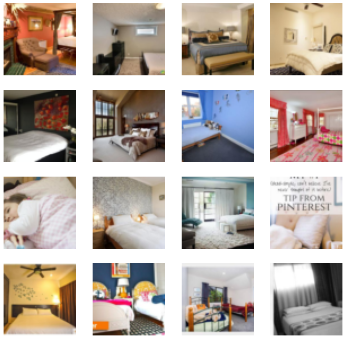

```python
dls.show_batch(max_n=16)
```

{% endraw %}

## GAN Learner

{% raw %}

`gan_loss_from_func`[[source]](https://github.com/fastai/fastai/tree/master/fastai/vision/gan.py#L347)

> `gan_loss_from_func`(**`loss_gen`**:`callable`, **`loss_crit`**:`callable`, **`weights_gen`**:`(None, list, tuple)`=*`None`*)

Define loss functions for a GAN from `loss_gen` and `loss_crit`.

|  | Type | Default | Details |
| --- | --- | --- | --- |
| **`loss_gen`** | `callable` |  | A loss function for the generator. Evaluates generator output images and target real images |
| **`loss_crit`** | `callable` |  | A loss function for the critic. Evaluates predictions of real and fake images. |
| **`weights_gen`** | `(None, list, tuple)` | `None` | Weights for the generator and critic loss function |

{% endraw %} {% raw %}

{% endraw %} {% raw %}

{% endraw %} {% raw %}

`class` `GANLearner`[[source]](https://github.com/fastai/fastai/tree/master/fastai/vision/gan.py#L370)

> `GANLearner`(**`dls`**:`DataLoaders`, **`generator`**:`nn.Module`, **`critic`**:`nn.Module`, **`gen_loss_func`**:`callable`, **`crit_loss_func`**:`callable`, **`switcher`**:`(Callback, None)`=*`None`*, **`gen_first`**:`bool`=*`False`*, **`switch_eval`**:`bool`=*`True`*, **`show_img`**:`bool`=*`True`*, **`clip`**:`(None, float)`=*`None`*, **`cbs`**:`(Callback, None, list)`=*`None`*, **`metrics`**:`(None, list, callable)`=*`None`*, **`loss_func`**=*`None`*, **`opt_func`**=*`Adam`*, **`lr`**=*`0.001`*, **`splitter`**=*`trainable_params`*, **`path`**=*`None`*, **`model_dir`**=*`'models'`*, **`wd`**=*`None`*, **`wd_bn_bias`**=*`False`*, **`train_bn`**=*`True`*, **`moms`**=*`(0.95, 0.85, 0.95)`*) :: `Learner`

A `Learner` suitable for GANs.

|  | Type | Default | Details |
| --- | --- | --- | --- |
| **`dls`** | `DataLoaders` |  | DataLoaders object for GAN data |
| **`generator`** | `nn.Module` |  | Generator model |
| **`critic`** | `nn.Module` |  | Critic model |
| **`gen_loss_func`** | `callable` |  | Generator loss function |
| **`crit_loss_func`** | `callable` |  | Critic loss function |
| **`switcher`** | `(Callback, None)` | `None` | Callback for switching between generator and critic training, defaults to `FixedGANSwitcher` |
| **`gen_first`** | `bool` | `False` | Whether we start with generator training |
| **`switch_eval`** | `bool` | `True` | Whether the model should be set to eval mode when calculating loss |
| **`show_img`** | `bool` | `True` | Whether to show example generated images during training |
| **`clip`** | `(None, float)` | `None` | How much to clip the weights |
| **`cbs`** | `(Callback, None, list)` | `None` | Additional callbacks |
| **`metrics`** | `(None, list, callable)` | `None` | Metrics |
|  |  | **Valid Keyword Arguments** |  |
| **`loss_func`** |  | `None` | Argument passed to `Learner.__init__` |
| **`opt_func`** | `function` | `Adam` | Argument passed to `Learner.__init__` |
| **`lr`** | `float` | `0.001` | Argument passed to `Learner.__init__` |
| **`splitter`** | `function` | `trainable_params` | Argument passed to `Learner.__init__` |
| **`path`** |  | `None` | Argument passed to `Learner.__init__` |
| **`model_dir`** | `str` | `models` | Argument passed to `Learner.__init__` |
| **`wd`** |  | `None` | Argument passed to `Learner.__init__` |
| **`wd_bn_bias`** | `bool` | `False` | Argument passed to `Learner.__init__` |
| **`train_bn`** | `bool` | `True` | Argument passed to `Learner.__init__` |
| **`moms`** | `tuple` | `(0.95, 0.85, 0.95)` | Argument passed to `Learner.__init__` |

{% endraw %} {% raw %}

{% endraw %} {% raw %}

`GANLearner.from_learners`[[source]](https://github.com/fastai/fastai/tree/master/fastai/vision/gan.py#L396)

> `GANLearner.from_learners`(**`gen_learn`**:`Learner`, **`crit_learn`**:`Learner`, **`switcher`**:`(Callback, None)`=*`None`*, **`weights_gen`**:`(None, list, tuple)`=*`None`*, **`gen_first`**:`bool`=*`False`*, **`switch_eval`**:`bool`=*`True`*, **`show_img`**:`bool`=*`True`*, **`clip`**:`(None, float)`=*`None`*, **`cbs`**:`(Callback, None, list)`=*`None`*, **`metrics`**:`(None, list, callable)`=*`None`*, **`loss_func`**=*`None`*, **`opt_func`**=*`Adam`*, **`lr`**=*`0.001`*, **`splitter`**=*`trainable_params`*, **`path`**=*`None`*, **`model_dir`**=*`'models'`*, **`wd`**=*`None`*, **`wd_bn_bias`**=*`False`*, **`train_bn`**=*`True`*, **`moms`**=*`(0.95, 0.85, 0.95)`*)

Create a GAN from `learn_gen` and `learn_crit`.

|  | Type | Default | Details |
| --- | --- | --- | --- |
| **`gen_learn`** | `Learner` |  | A `Learner` object that contains the generator |
| **`crit_learn`** | `Learner` |  | A `Learner` object that contains the critic |
| **`switcher`** | `(Callback, None)` | `None` | Callback for switching between generator and critic training, defaults to `FixedGANSwitcher` |
| **`weights_gen`** | `(None, list, tuple)` | `None` | Weights for the generator and critic loss function |
|  |  | **Valid Keyword Arguments** |  |
| **`gen_first`** | `bool` | `False` | Whether we start with generator training passed to `GANLearner.__init__` |
| **`switch_eval`** | `bool` | `True` | Whether the model should be set to eval mode when calculating loss passed to `GANLearner.__init__` |
| **`show_img`** | `bool` | `True` | Whether to show example generated images during training passed to `GANLearner.__init__` |
| **`clip`** | `(None, float)` | `None` | How much to clip the weights passed to `GANLearner.__init__` |
| **`cbs`** | `(Callback, None, list)` | `None` | Additional callbacks passed to `GANLearner.__init__` |
| **`metrics`** | `(None, list, callable)` | `None` | Metrics passed to `GANLearner.__init__` |
| **`loss_func`** |  | `None` | Argument passed to `GANLearner.__init__` |
| **`opt_func`** | `function` | `Adam` | Argument passed to `GANLearner.__init__` |
| **`lr`** | `float` | `0.001` | Argument passed to `GANLearner.__init__` |
| **`splitter`** | `function` | `trainable_params` | Argument passed to `GANLearner.__init__` |
| **`path`** |  | `None` | Argument passed to `GANLearner.__init__` |
| **`model_dir`** | `str` | `models` | Argument passed to `GANLearner.__init__` |
| **`wd`** |  | `None` | Argument passed to `GANLearner.__init__` |
| **`wd_bn_bias`** | `bool` | `False` | Argument passed to `GANLearner.__init__` |
| **`train_bn`** | `bool` | `True` | Argument passed to `GANLearner.__init__` |
| **`moms`** | `tuple` | `(0.95, 0.85, 0.95)` | Argument passed to `GANLearner.__init__` |

{% endraw %} {% raw %}

`GANLearner.wgan`[[source]](https://github.com/fastai/fastai/tree/master/fastai/vision/gan.py#L408)

> `GANLearner.wgan`(**`dls`**:`DataLoaders`, **`generator`**:`nn.Module`, **`critic`**:`nn.Module`, **`switcher`**:`(Callback, None)`=*`None`*, **`clip`**:`(None, float)`=*`0.01`*, **`switch_eval`**:`bool`=*`False`*, **`gen_first`**:`bool`=*`False`*, **`show_img`**:`bool`=*`True`*, **`cbs`**:`(Callback, None, list)`=*`None`*, **`metrics`**:`(None, list, callable)`=*`None`*, **`loss_func`**=*`None`*, **`opt_func`**=*`Adam`*, **`lr`**=*`0.001`*, **`splitter`**=*`trainable_params`*, **`path`**=*`None`*, **`model_dir`**=*`'models'`*, **`wd`**=*`None`*, **`wd_bn_bias`**=*`False`*, **`train_bn`**=*`True`*, **`moms`**=*`(0.95, 0.85, 0.95)`*)

Create a [WGAN](https://arxiv.org/abs/1701.07875) from `dls`, `generator` and `critic`.

|  | Type | Default | Details |
| --- | --- | --- | --- |
| **`dls`** | `DataLoaders` |  | DataLoaders object for GAN data |
| **`generator`** | `nn.Module` |  | Generator model |
| **`critic`** | `nn.Module` |  | Critic model |
| **`switcher`** | `(Callback, None)` | `None` | Callback for switching between generator and critic training, defaults to `FixedGANSwitcher(n_crit=5, n_gen=1)` |
| **`clip`** | `(None, float)` | `0.01` | How much to clip the weights |
| **`switch_eval`** | `bool` | `False` | Whether the model should be set to eval mode when calculating loss |
|  |  | **Valid Keyword Arguments** |  |
| **`gen_first`** | `bool` | `False` | Whether we start with generator training passed to `GANLearner.__init__` |
| **`show_img`** | `bool` | `True` | Whether to show example generated images during training passed to `GANLearner.__init__` |
| **`cbs`** | `(Callback, None, list)` | `None` | Additional callbacks passed to `GANLearner.__init__` |
| **`metrics`** | `(None, list, callable)` | `None` | Metrics passed to `GANLearner.__init__` |
| **`loss_func`** |  | `None` | Argument passed to `GANLearner.__init__` |
| **`opt_func`** | `function` | `Adam` | Argument passed to `GANLearner.__init__` |
| **`lr`** | `float` | `0.001` | Argument passed to `GANLearner.__init__` |
| **`splitter`** | `function` | `trainable_params` | Argument passed to `GANLearner.__init__` |
| **`path`** |  | `None` | Argument passed to `GANLearner.__init__` |
| **`model_dir`** | `str` | `models` | Argument passed to `GANLearner.__init__` |
| **`wd`** |  | `None` | Argument passed to `GANLearner.__init__` |
| **`wd_bn_bias`** | `bool` | `False` | Argument passed to `GANLearner.__init__` |
| **`train_bn`** | `bool` | `True` | Argument passed to `GANLearner.__init__` |
| **`moms`** | `tuple` | `(0.95, 0.85, 0.95)` | Argument passed to `GANLearner.__init__` |

{% endraw %} {% raw %}

```python
from fastai.callback.all import *
```

{% endraw %} {% raw %}

```python
generator = basic_generator(64, n_channels=3, n_extra_layers=1)
critic    = basic_critic   (64, n_channels=3, n_extra_layers=1, act_cls=partial(nn.LeakyReLU, negative_slope=0.2))
```

{% endraw %} {% raw %}

```python
learn = GANLearner.wgan(dls, generator, critic, opt_func = RMSProp)
```

{% endraw %} {% raw %}

```python
learn.recorder.train_metrics=True
learn.recorder.valid_metrics=False
```

{% endraw %} {% raw %}

```python
learn.fit(1, 2e-4, wd=0.)
```

| epoch | train_loss | gen_loss | crit_loss | time |
| --- | --- | --- | --- | --- |
| 0 | -0.815071 | 0.646809 | -1.140522 | 00:38 |

{% endraw %} {% raw %}

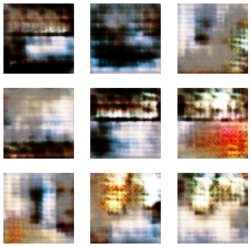

```python
learn.show_results(max_n=9, ds_idx=0)
```

{% endraw %}